# Cluster Analysis

## features_20190311_systIII_siPOOLs_plate1_singlePulses.csv

Loading of the necessary Data and transfering

```r
data.clean = data.table::fread(filename.features)
dt.data = fread(filename.tdata)
```

Pool all the WT and negative as well as posive CTRL together

```r
features.clean.pooled = data.clean %>% mutate(Stimulation_treatment = case_when(
  Stimulation_treatment %like% "\\+CTRL" ~ "+CTRL",
  Stimulation_treatment %like% "\\-CTRL" ~ "-CTRL",
  Stimulation_treatment %like% "WT" ~ "WT",
  TRUE ~ as.character(Stimulation_treatment)
) )
```

Normalisation of the data

```r
source("normalize_data_frame.R")
data.pooled.n = normalize_frame(features.clean.pooled, -Image_Metadata_Site, -objNuc_TrackObjects_Label)
```

Create named matrix of the normalized features

```r
names = data.pooled.n$Stimulation_treatment
cluster.data.n = data.pooled.n %>% ungroup()  %>%
  select(-Image_Metadata_Site, -objNuc_TrackObjects_Label) %>% #, -dip.time.min, -mean, -sd, -FMWH.left, -FMWH.right, -noise) %>%
  select_if(is.numeric)
m = as.matrix(cluster.data.n)
rownames(m) = names
```

Create distance matrx and cluster with hc clust

```r
distance_m = dist(m, method = "euclidean")
hr <- hclust(distance_m, method = "ward.D2")
```

Clustered Heatmap of features with 5 Clusters

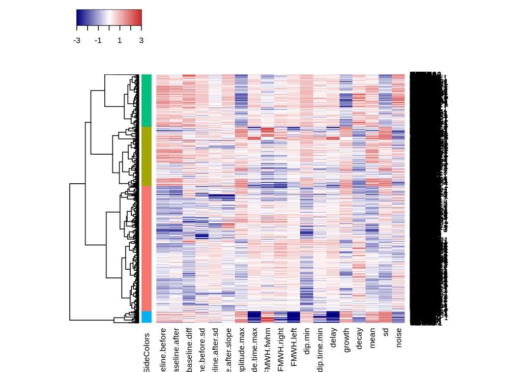

```r
mycl <- cutree(hr, k = k)
cl = as.factor(mycl)
gg_color_hue <- function(n) {
  hues = seq(15, 375, length = n + 1)
  hcl(h = hues, l = 65, c = 100)[1:n]
}
mycolhc <- gg_color_hue(k)
mycolhc_c <- mycolhc[as.integer(as.vector(cl))]
m_clipped = m # hard clipping, ouliers disturbe colors
m_clipped[m_clipped > 3 ] = 3
m_clipped[m_clipped < -3] = -3
heatmap3(m_clipped, Rowv =as.dendrogram(hr), Colv = NA, scale = "none", RowSideColors = mycolhc_c)
```

Heat map but with Columns clustered aswell

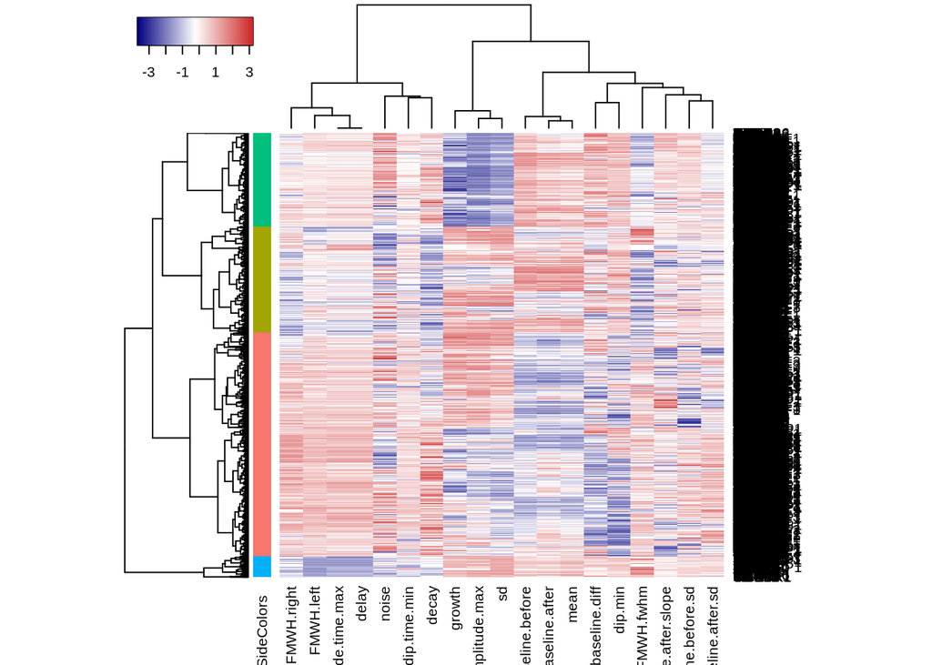

```r
distance_m_c = dist(t(m), method = "euclidean")
hc <- hclust(distance_m_c, method = "ward.D")
heatmap3(m_clipped, Rowv =as.dendrogram(hr), Colv = as.dendrogram(hc), RowSideColors = mycolhc_c)
```

From dendrogram, get cluster information and create cluster distance plot.

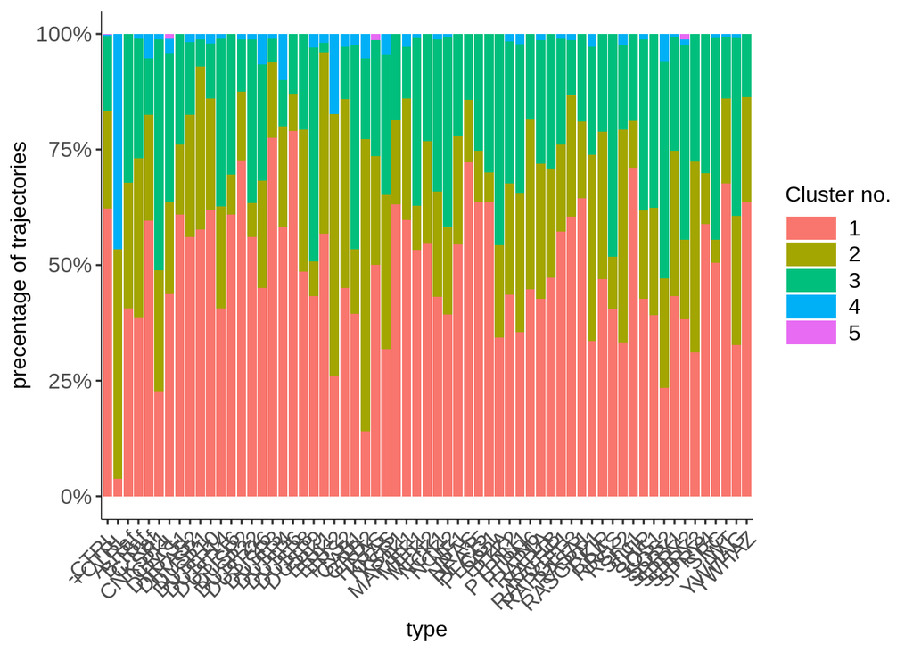

```r
cluster.freq = data.frame(cl = as.vector(mycl), type = names(mycl))
summ = cluster.freq %>% group_by(cl, type) %>% summarise(count = n())  %>% ungroup() %>% mutate(cl = as.factor(cl))

ggplot(summ,aes(x = type, y = count, fill = cl)) +
    geom_bar(position = position_fill(reverse = TRUE),stat = "identity") +
    scale_y_continuous(labels = scales::percent_format()) +
    ggplotTheme() + theme(axis.text.x = element_text(angle = 45, hjust = 1)) +
    labs(y = "precentage of trajectories", fill = "Cluster no.")
```

File containing for the Features and therefore for the unique label in which clusters it belongs. Merge with time series data to plot cluster averages

Analyse clusters averages

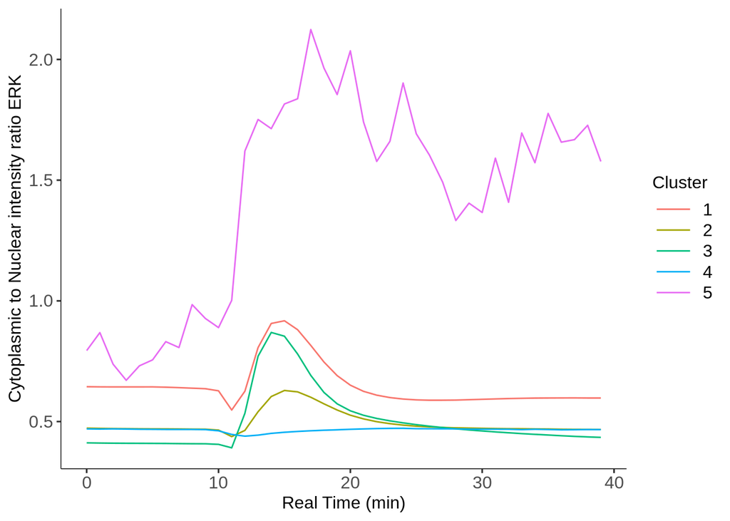

```r
# should still have same ordering as features table
cluster.freq$Image_Metadata_Site = data.clean$Image_Metadata_Site
cluster.freq$objNuc_TrackObjects_Label = data.clean$objNuc_TrackObjects_Label

timeseries.clustered = left_join(cluster.freq, dt.data)

summarised_clusters = timeseries.clustered %>%
  mutate(cl = as.factor(cl)) %>%
  group_by(cl, RealTime) %>% summarise(mean_cl_at_t = mean(erk.ratio))

ggplot(summarised_clusters, aes(y = mean_cl_at_t, x = RealTime, color =  cl, group = cl)) +
  geom_line() +
  labs(x = "Real Time (min)" , y = "Cytoplasmic to Nuclear intensity ratio ERK", color = "Cluster") +
  ggplotTheme()
```

Clusters as exported from shiny app

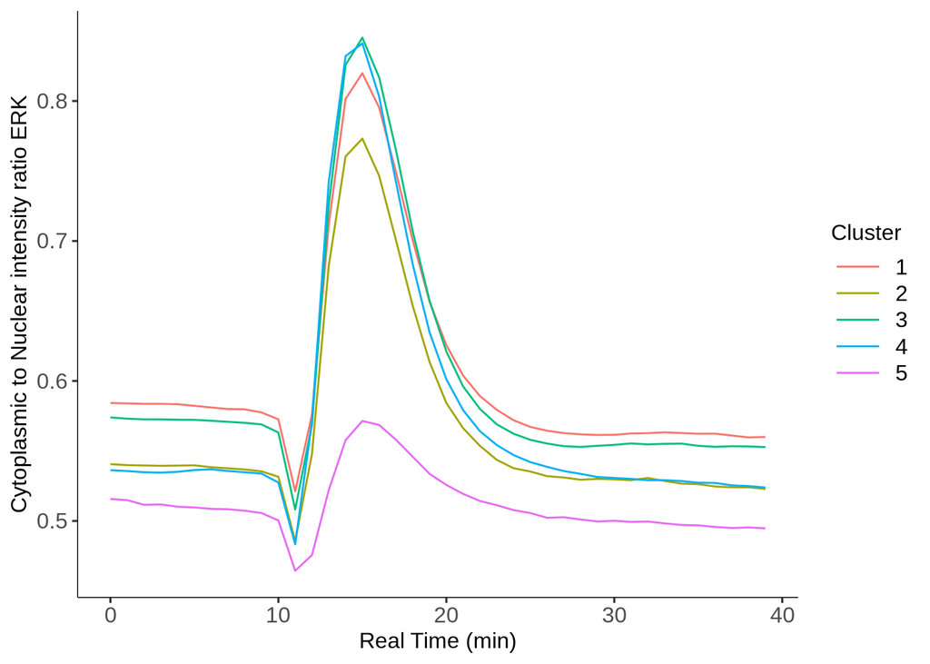

```r
cluster.to.unique = fread("clusternalysisdata/tabClHier-downCellCl")
cluster.to.unique <- cluster.to.unique %>% separate(id, c('Image_Metadata_Site', 'objNuc_TrackObjects_Label')) %>% mutate_all(as.numeric)
timeseries.clustered = left_join(cluster.to.unique, dt.data)

summarised_clusters = timeseries.clustered %>%
  mutate(cl = as.factor(cl)) %>%
  group_by(cl, RealTime) %>% summarise(mean_cl_at_t = mean(erk.ratio))

ggplot(summarised_clusters, aes(y = mean_cl_at_t, x = RealTime, color =  cl, group = cl)) +
  geom_line() +
  labs(x = "Real Time (min)" , y = "Cytoplasmic to Nuclear intensity ratio ERK", color = "Cluster") +
  ggplotTheme()
```

## train a randomForest classifier on the features. Create a model that predicts Stimulation_Treatment and look at feature importance.

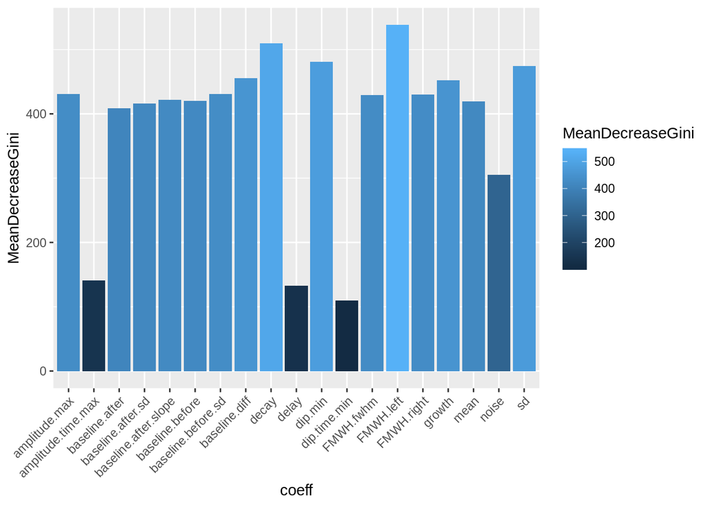

```r
pacman::p_load(randomForest)
#rnd.features = data.clean
rnd.features = features.clean.pooled
rnd.features[is.na(rnd.features)] = 1000
rnd.features$Image_Metadata_Site = NULL
rnd.features$objNuc_TrackObjects_Label = NULL
rnd.features$Stimulation_treatment = as.factor(rnd.features$Stimulation_treatment)
forest_class = randomForest(Stimulation_treatment~.,rnd.features)
coeff = as.data.table(importance(forest_class))
coeff$coeff = rownames(importance(forest_class))


ggplot(coeff, aes(y = MeanDecreaseGini, x = coeff, fill = MeanDecreaseGini)) +
  geom_bar(stat = "identity")+
  theme(axis.text.x = element_text(angle = 45, hjust = 1))
```

## Repetition of clustering Analysis with only important features according to random Forest

```r
arrange(coeff, MeanDecreaseGini)[-(1:5),]$coeff
```

```
##  [1] "baseline.after.sd"    "mean"                 "baseline.before"
##  [4] "baseline.after.slope" "FMWH.fwhm"            "FMWH.right"
##  [7] "amplitude.max"        "baseline.before.sd"   "growth"
## [10] "baseline.diff"        "sd"                   "dip.min"
## [13] "decay"                "FMWH.left"
```

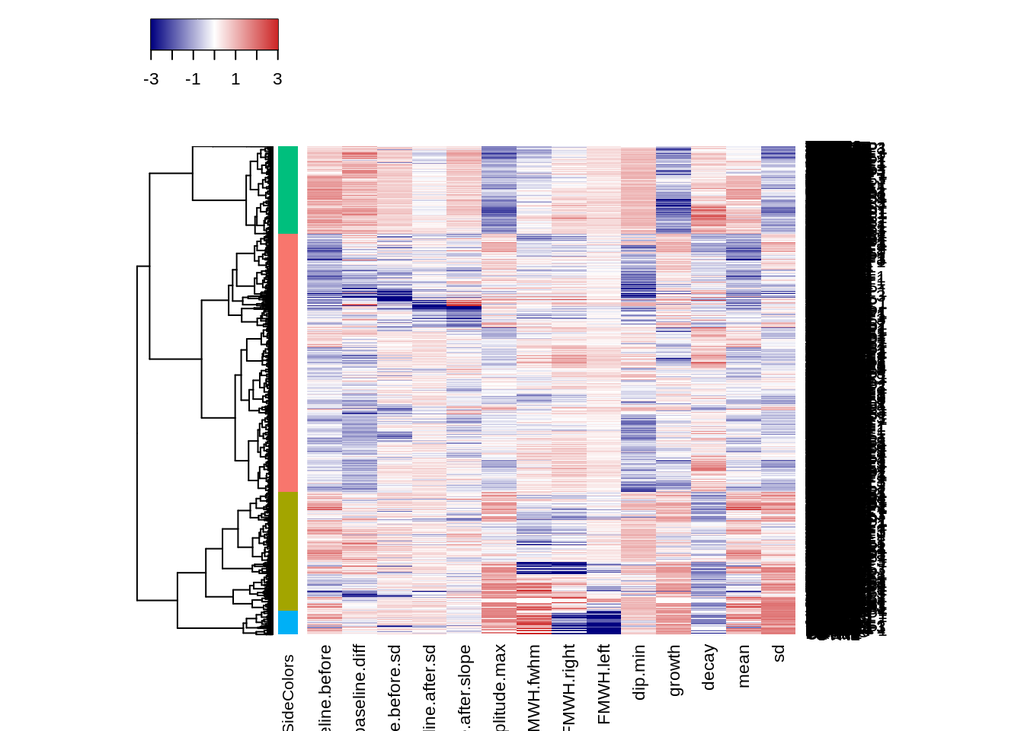

```r
names = data.pooled.n$Stimulation_treatment
cluster.data.n = data.pooled.n %>% ungroup()  %>%
  select(-Image_Metadata_Site, -objNuc_TrackObjects_Label) %>% select(-c(arrange(coeff, MeanDecreaseGini)[1:5,]$coeff)) %>%#, -dip.time.min, -mean, -sd, -FMWH.left, -FMWH.right, -noise) %>%
  select_if(is.numeric)
m = as.matrix(cluster.data.n)
rownames(m) = names
distance_m = dist(m, method = "euclidean")
hr <- hclust(distance_m, method = "ward.D2")
mycl <- cutree(hr, k = k)
cl = as.factor(mycl)
gg_color_hue <- function(n) {
  hues = seq(15, 375, length = n + 1)
  hcl(h = hues, l = 65, c = 100)[1:n]
}
mycolhc <- gg_color_hue(k)
mycolhc_c <- mycolhc[as.integer(as.vector(cl))]
m_clipped = m # hard clipping, ouliers disturbe colors
m_clipped[m_clipped > 3 ] = 3
m_clipped[m_clipped < -3] = -3
heatmap3(m_clipped, Rowv =as.dendrogram(hr), Colv = NA, scale = "none", RowSideColors = mycolhc_c)
```

Heat map but with Columns clustered aswell

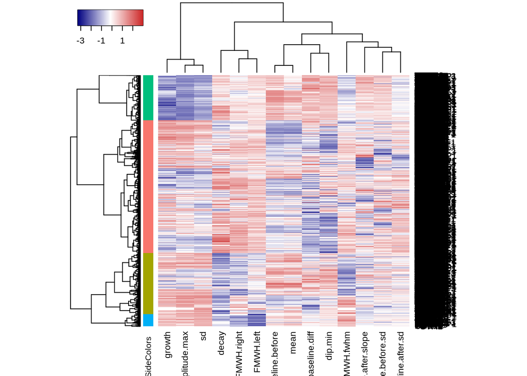

```r
distance_m_c = dist(t(m), method = "euclidean")
hc <- hclust(distance_m_c, method = "ward.D")
heatmap3(m_clipped, Rowv =as.dendrogram(hr), Colv = as.dendrogram(hc), RowSideColors = mycolhc_c)
```

From dendrogram, get cluster information and create cluster distance plot.

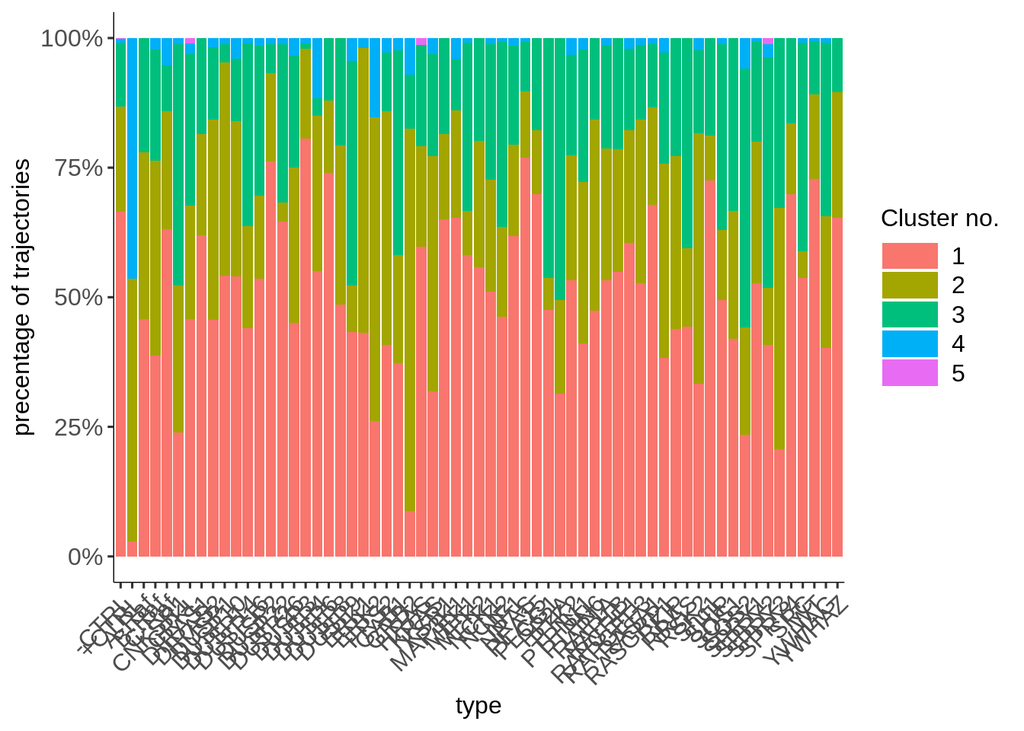

```r
cluster.freq = data.frame(cl = as.vector(mycl), type = names(mycl))
summ = cluster.freq %>% group_by(cl, type) %>% summarise(count = n())  %>% ungroup() %>% mutate(cl = as.factor(cl))

ggplot(summ,aes(x = type, y = count, fill = cl)) +
    geom_bar(position = position_fill(reverse = TRUE),stat = "identity") +
    scale_y_continuous(labels = scales::percent_format()) +
    ggplotTheme() + theme(axis.text.x = element_text(angle = 45, hjust = 1)) +
    labs(y = "precentage of trajectories", fill = "Cluster no.")
```

File containing for the Features and therefore for the unique label in which clusters it belongs. Merge with time series data to plot cluster averages

Analyse clusters averages

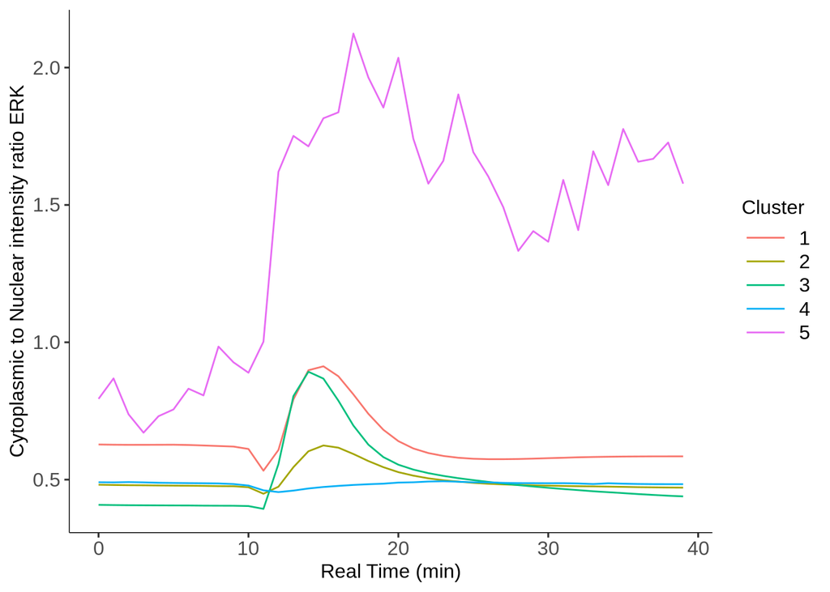

```r
# should still have same ordering as features table
cluster.freq$Image_Metadata_Site = data.clean$Image_Metadata_Site
cluster.freq$objNuc_TrackObjects_Label = data.clean$objNuc_TrackObjects_Label

timeseries.clustered = left_join(cluster.freq, dt.data)

summarised_clusters = timeseries.clustered %>%
  mutate(cl = as.factor(cl)) %>%
  group_by(cl, RealTime) %>% summarise(mean_cl_at_t = mean(erk.ratio))

ggplot(summarised_clusters, aes(y = mean_cl_at_t, x = RealTime, color =  cl, group = cl)) +
  geom_line() +
  labs(x = "Real Time (min)" , y = "Cytoplasmic to Nuclear intensity ratio ERK", color = "Cluster") +
  ggplotTheme()
```

## Remove positive CTRL from clustering

This is sensable because +CTRL uses almost two hole clusters for itself. But we can use one sluter more.

```r
k = 6 # without +CTRL is ok
arrange(coeff, MeanDecreaseGini)[-(1:5),]$coeff
```

```
##  [1] "baseline.after.sd"    "mean"                 "baseline.before"
##  [4] "baseline.after.slope" "FMWH.fwhm"            "FMWH.right"
##  [7] "amplitude.max"        "baseline.before.sd"   "growth"
## [10] "baseline.diff"        "sd"                   "dip.min"
## [13] "decay"                "FMWH.left"
```

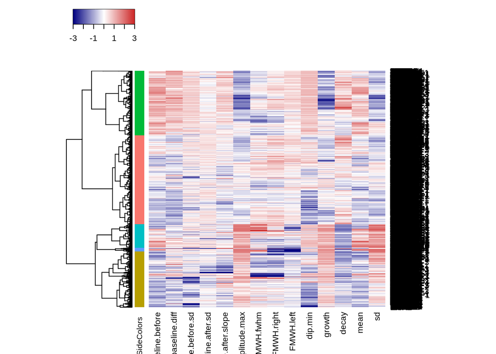

```r
data.pooled = data.clean %>%
  filter(!get(stim.var) %like% "\\+CTRL") %>%
  mutate(Stimulation_treatment = case_when(Stimulation_treatment %like% "WT" ~ "WT",
                                           Stimulation_treatment %like% "CTRL" ~ "-CTRL",
                                           TRUE ~ as.character(Stimulation_treatment)))
data.pooled.n = normalize_frame(data.pooled, -Image_Metadata_Site, -objNuc_TrackObjects_Label)


names = data.pooled.n$Stimulation_treatment
cluster.data.n = data.pooled.n %>% ungroup()  %>%
  select(-Image_Metadata_Site, -objNuc_TrackObjects_Label) %>% select(-c(arrange(coeff, MeanDecreaseGini)[1:5,]$coeff)) %>%#, -dip.time.min, -mean, -sd, -FMWH.left, -FMWH.right, -noise) %>%
  select_if(is.numeric)
m = as.matrix(cluster.data.n)
rownames(m) = names
distance_m = dist(m, method = "euclidean")
hr <- hclust(distance_m, method = "ward.D2")
mycl <- cutree(hr, k = k)
cl = as.factor(mycl)
gg_color_hue <- function(n) {
  hues = seq(15, 375, length = n + 1)
  hcl(h = hues, l = 65, c = 100)[1:n]
}
mycolhc <- gg_color_hue(k)
mycolhc_c <- mycolhc[as.integer(as.vector(cl))]
m_clipped = m # hard clipping, ouliers disturbe colors
m_clipped[m_clipped > 3 ] = 3
m_clipped[m_clipped < -3] = -3
heatmap3(m_clipped, Rowv =as.dendrogram(hr), Colv = NA, scale = "none", RowSideColors = mycolhc_c)
```

Heat map but with Columns clustered aswell

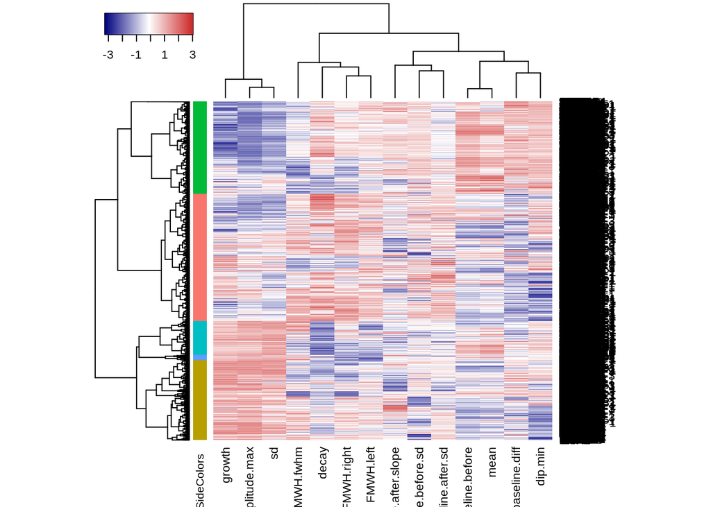

```r
distance_m_c = dist(t(m), method = "euclidean")
hc <- hclust(distance_m_c, method = "ward.D")
heatmap3(m_clipped, Rowv =as.dendrogram(hr), Colv = as.dendrogram(hc), RowSideColors = mycolhc_c)
```

From dendrogram, get cluster information and create cluster distance plot.

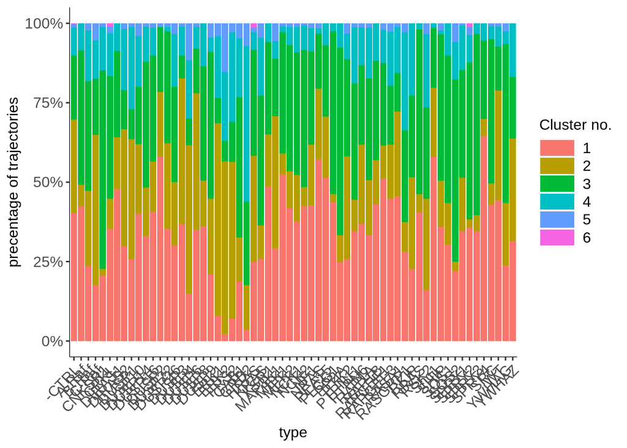

```r
cluster.freq = data.frame(cl = as.vector(mycl), type = names(mycl))
summ = cluster.freq %>% group_by(cl, type) %>% summarise(count = n())  %>% ungroup() %>% mutate(cl = as.factor(cl))

ggplot(summ,aes(x = type, y = count, fill = cl)) +
    geom_bar(position = position_fill(reverse = TRUE),stat = "identity") +
    scale_y_continuous(labels = scales::percent_format()) +
    ggplotTheme() + theme(axis.text.x = element_text(angle = 45, hjust = 1)) +
    labs(y = "precentage of trajectories", fill = "Cluster no.")
```

File containing for the Features and therefore for the unique label in which clusters it belongs. Merge with time series data to plot cluster averages

Analyse clusters averages

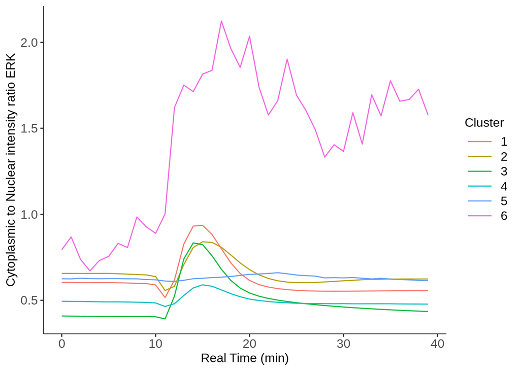

```r
# should still have same ordering as features table

cluster.freq$Image_Metadata_Site = data.pooled.n$Image_Metadata_Site
cluster.freq$objNuc_TrackObjects_Label = data.pooled.n$objNuc_TrackObjects_Label

timeseries.clustered = left_join(cluster.freq, dt.data)

summarised_clusters = timeseries.clustered %>%
  mutate(cl = as.factor(cl)) %>%
  group_by(cl, RealTime) %>% summarise(mean_cl_at_t = mean(erk.ratio))

ggplot(summarised_clusters, aes(y = mean_cl_at_t, x = RealTime, color =  cl, group = cl)) +
  geom_line() +
  labs(x = "Real Time (min)" , y = "Cytoplasmic to Nuclear intensity ratio ERK", color = "Cluster") +
  ggplotTheme()
```

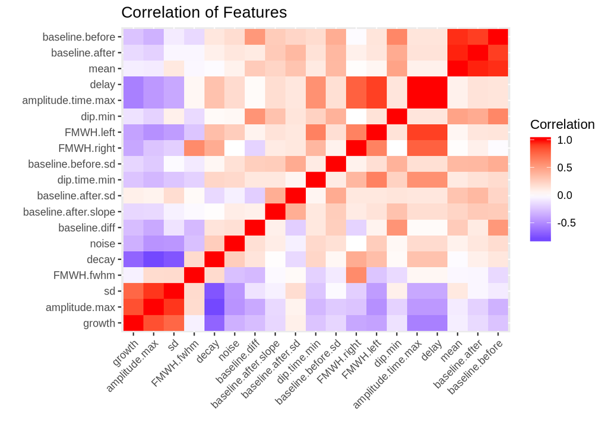

```r
names = data.pooled.n$Stimulation_treatment
cluster.data.n = data.pooled.n %>% ungroup()  %>%
  select(-Image_Metadata_Site, -objNuc_TrackObjects_Label) %>% #, -dip.time.min, -mean, -sd, -FMWH.left, -FMWH.right, -noise) %>%
  select_if(is.numeric)
m = as.matrix(cluster.data.n)
fcorr = cor(na.omit(m))
fcorr.df = data.frame(fcorr)
fcorr.df$type = rownames(fcorr.df)
cor.long = gather(fcorr.df, "type1","Correlation",-type)
ggplot(cor.long, aes(y = reorder(type, Correlation), x = reorder(type1, Correlation), fill = Correlation)) +
  geom_tile() + scale_fill_gradient2(low = "blue", high= "red", mid = "white") +
  theme(axis.text.x = element_text(angle = 45, hjust = 1)) + labs(title = "Correlation of Features" , x = "" , y = "")
```

Correlation after removing Features accoring to importance created by random Forest.

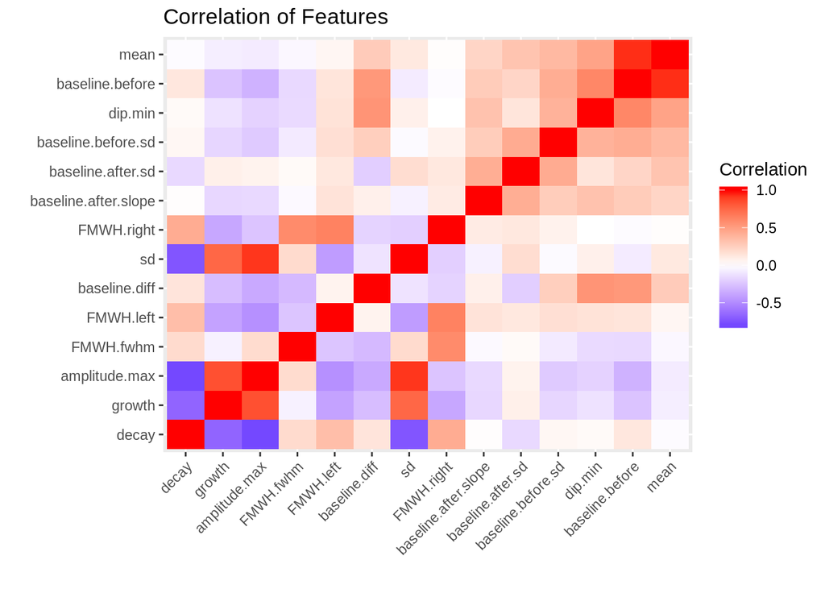

```r
names = data.pooled.n$Stimulation_treatment
cluster.data.n = data.pooled.n %>% ungroup()  %>%
  select(-Image_Metadata_Site, -objNuc_TrackObjects_Label) %>%
  select(-c(arrange(coeff, MeanDecreaseGini)[1:5,]$coeff)) %>% #, -dip.time.min, -mean, -sd, -FMWH.left, -FMWH.right, -noise) %>%
  select_if(is.numeric)
m = as.matrix(cluster.data.n)
fcorr = cor(na.omit(m))
fcorr.df = data.frame(fcorr)
fcorr.df$type = rownames(fcorr.df)
cor.long = gather(fcorr.df, "type1","Correlation",-type)
ggplot(cor.long, aes(y = reorder(type, Correlation), x = reorder(type1, Correlation), fill = Correlation)) +
  geom_tile() + scale_fill_gradient2(low = "blue", high= "red", mid = "white") +
  theme(axis.text.x = element_text(angle = 45, hjust = 1)) + labs(title = "Correlation of Features" , x = "" , y = "")
```

```r
require(Rtsne)

# try tsne stuff
labels = na.omit(data.pooled.n)$Stimulation_treatment
train<- data.pooled.n %>% select(-Image_Metadata_Site, -Image_Metadata_Site, -Stimulation_treatment)## Choose the train.csv file downloaded from the link above
## Curating the database for analysis with both t-SNE and PCA

labels<-as.factor(labels)
## for plotting
colors = rainbow(length(unique(labels)))
names(colors) = unique(labels)

## Executing the algorithm on curated data
tsne <- Rtsne(na.omit(train), dims = 2, perplexity=50, verbose=TRUE, max_iter = 1800, eta = 300)
```

[output not shown]

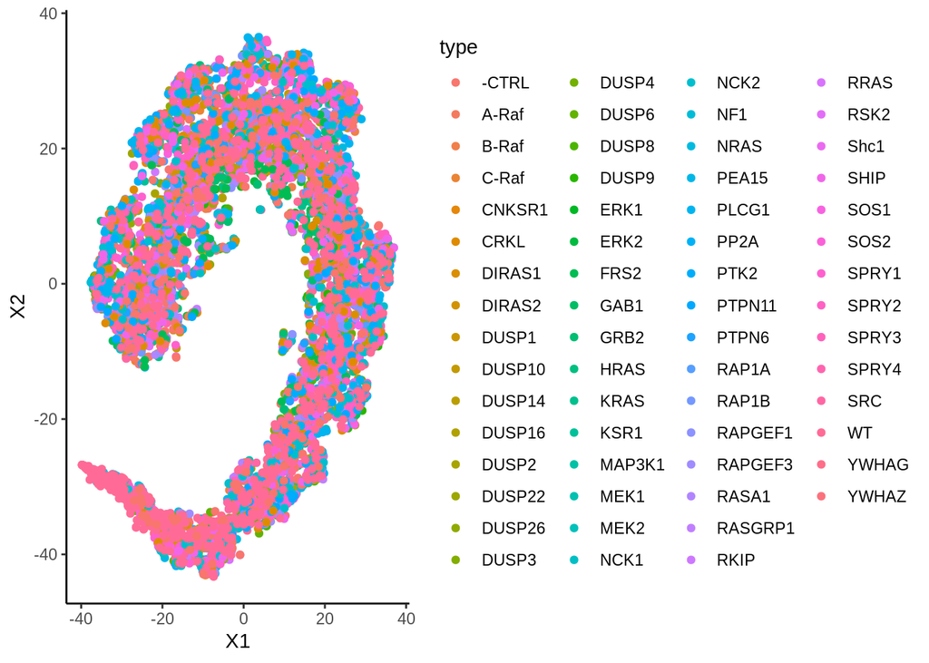

```r
## Plotting
x = data.frame(tsne$Y)
x$type = labels
ggplot(x, aes(x = X1, y = X2, color = type)) +
  geom_point() + theme_classic()
```